# Project - Pulsar Star

```r
library(tidyverse)
library(repr)
library(caret)
install.packages("DataExplorer")
library(DataExplorer)
install.packages("GGally")
library(GGally)
install.packages("e1071")
```

# Introduction:

### Background and Motivation：

Pulsars stars are the cores of stars that have collapsed into a Neutron star. These stars possess very powerful magnetic fields, causing beams of radio magnetic emissions to be released from their poles. These radio emissions are so powerful that they can be detected from Earth. Furthermore, another key characteristic of pulsar stars is that they are constantly spinning rapidly, causing their radio emissions to be perceived as a repeated pulse, or blinking, pattern.

While the existence of pulsar stars may appear insignificant at first, their characteristic of maintaining a constant spin along with the powerful magnetic fields they possess provide researchers with key insight towards the nature of the universe. More specifically, their main scientific usages are for analyzing the physics of neutron stars, calculating cosmic distances within space, and for discovering new planets. As a matter of fact, the very first exoplanets (planets outside of our Solar System) were discovered as a result of their close proximity to a pulsar star.

However, an obstacle faced by researchers studying pulsar stars is their ability to accurately determine if a detected radio emission originated from a pulsar star or from some other source. Before they can analyze the details of the radio emission, they must first confirm that it was produced by a pulsar. Unfortunately, the process of manually evaluating these radio emissions is incredibly laborious, thus reducing the amount of time actually spent upon studying the pulsars themselves. As a result, we would like to build and train a KNN Classification model that will not only be precise and accurate in identifying pulsars, but also rely upon less variables in order to further save computational power and time.

We will first build one knn model using all columns as predictors, build another knn model by removing the predictors that are likely to be insignificant. Specifically, then, our question is: **Can the model with less predictors yield a similar accuracy in identifying pulsars as the model built using all classifiers?** The wording in the question has been left purposely vague so as to allow for some flexibility in our conclusions (as we are not sure what we will find). For example, we are not sure whether we will find 1 or 2 or even more potentially insignificant feature, so we are not sure how many predictors will be included in our second model.

Our hypothesis is that after removing the potentially insignificant predictor(s), we would still be able to build a model that yields a similar accuracy, if not higher accuracy, for the prediction of pulsar stars.

### Dataset

We will be using the UCI Machine Learning Repository Polsar Star dataset. It is composed of 9 columns, with 8 representing continuous variables and one as the class variable, which represents the status of the candidate (a potential signal detection) as a pulsar star or not. In regards to the class column, a value of 1 means that the candidate did indeed originate from a pulsar, while a value of 0 means that the candidate originated from some other source.

The first four predictor variables are simple statistics/characteristics of the radio emission that is obtained from the Integrated Pulse Profile, which is identified as the intensity of the radio emissions being detected. The remaining four predictor variables are also characteristics of the radio emission except that these are obtained from the DM-SNR curve, which is the relationship between the Dispersion Measure (the distance and electron density between Earth and the signal origin) and the Signal-to-Noise Ratio (the level of desired signal compared to the level of background noise).

More specifically, for both the Integrated Pulse Profile and DM-SNR curve of each candidate, the simple statistics consists of the mean, the standard deviation, the excess kurtosis, and the skewness.

The mean of the Integrated Pulse Profile represents the average intensity of the radio wave, the standard deviation represents the dispersion in the wave’s intensity from the calculated mean, the excess kurtosis represents how significantly the tails (endpoints) of the radio wave differ from that of the normal distribution, and the skewness represents how distorted and asymmetrical the radio wave is.

The mean of the DM-SNR curve represents the average relationship between the Dispersion Measure and the Signal-to-Noise Ratio of the candidate, the standard deviation represents the dispersion in the relationship from the calculated mean, the excess kurtosis represents how significantly the tails (endpoints) of the relationship (when its distribution is plotted) differ from that of the normal distribution, and the skewness represents how distorted and asymmetrical the relationship is when its distribution is plotted.

## Method

1. Split the available data into a training and testing set
2. Standardize the data
3. Remove all the rows with missing data
4. Determine which column could potentially be an ineffective predictor using pairs plot and logistic regression.
5. Train a knn classification model with Cross Validation to determine the best k-value
6. Train the final model with the best k-value found, and
7. Assess model by calculating training and testing accuracies
8. Mutate the original dataset by unselecting the ineffective predictor
9. Repeat steps 5-7 on the mutated dataset from step 8
10. Compare the accuracies of predictions generated from the two different models

##### **We will sometimes refer to the model trained by all predictors as "model 1", and the model trained by the mutated dataset as "model 2".**

## Content

##### - A. Data cleaning and wrangling

##### - B. Determining the potentially ineffective column

##### - C. Train and access first model, which uses all columns as predictors

# A1. Download the Dataset:

We first download the data from google drive and add column names to each of the columns.

```r
pulsar_star.csv.zip = download.file("https://drive.google.com/uc?export=download&id=1YYVwOzkm6jRd5AyZqaEjJPfD9QpLRkNm",
                                    destfile = "data/pulsar_star.zip",
                                    mode = "wb")
pulsar_star = read_csv(unzip("data/pulsar_star.zip"), skip = 1, col_name = FALSE)
names(pulsar_star) = c("ip_mean","ip_sd","ip_excess_kurtosis","ip_skewness",
                       "DM_mean","DM_sd", "DM_excess_kurtosis","DM_skewness","class")

pulsar_star <- pulsar_star %>%
  mutate(class = as.factor(class))


head(pulsar_star)
```

A tibble: 6 × 9

| ip_mean <dbl> | ip_sd <dbl> | ip_excess_kurtosis <dbl> | ip_skewness <dbl> | DM_mean <dbl> | DM_sd <dbl> | DM_excess_kurtosis <dbl> | DM_skewness <dbl> | class <fct> |
| --- | --- | --- | --- | --- | --- | --- | --- | --- |
| 140.56250 | 55.68378 | -0.23457141 | -0.6996484 | 3.199833 | 19.11043 | 7.975532 | 74.24222 | 0 |
| 102.50781 | 58.88243 | 0.46531815 | -0.5150879 | 1.677258 | 14.86015 | 10.576487 | 127.39358 | 0 |
| 103.01562 | 39.34165 | 0.32332837 | 1.0511644 | 3.121237 | 21.74467 | 7.735822 | 63.17191 | 0 |
| 136.75000 | 57.17845 | -0.06841464 | -0.6362384 | 3.642977 | 20.95928 | 6.896499 | 53.59366 | 0 |
| 88.72656 | 40.67223 | 0.60086608 | 1.1234917 | 1.178930 | 11.46872 | 14.269573 | 252.56731 | 0 |
| 93.57031 | 46.69811 | 0.53190485 | 0.4167211 | 1.636288 | 14.54507 | 10.621748 | 131.39400 | 0 |

# A2. Overview of the dataset:

We the partition the data into a training set and testing set by 75/25 ratio. Summary statistics show that our training dataset consists of a total of 13367 rows, including 13366 complete rows and 1 row with missing data. Among all the complete rows, there are 12137 non pulsar observations and 1229 actual pulsar observations. The summary statistics also provide an overview of the mean, quartile range, and extreme values in of each column.

```r
set.seed(1)

training_rows <- pulsar_star %>%
  select(class) %>%
  unlist() %>%
  createDataPartition(p = 0.75, list = FALSE)

training_set <- pulsar_star %>% slice(training_rows)
testing_set <- pulsar_star %>% slice(-training_rows)


introduce(training_set)
summary(training_set)
```

A spec_tbl_df: 1 × 9

| rows <int> | columns <int> | discrete_columns <int> | continuous_columns <int> | all_missing_columns <int> | total_missing_values <int> | complete_rows <int> | total_observations <int> | memory_usage <dbl> |
| --- | --- | --- | --- | --- | --- | --- | --- | --- |
| 13367 | 9 | 1 | 8 | 0 | 4 | 13366 | 120303 | 912392 |

```
    ip_mean           ip_sd       ip_excess_kurtosis  ip_skewness
 Min.   :  6.18   Min.   :24.77   Min.   :-1.87601   Min.   :-1.7919
 1st Qu.:100.75   1st Qu.:42.34   1st Qu.: 0.02843   1st Qu.:-0.1898
 Median :115.00   Median :46.94   Median : 0.22469   Median : 0.1976
 Mean   :110.95   Mean   :46.53   Mean   : 0.48229   Mean   : 1.7969
 3rd Qu.:126.97   3rd Qu.:51.00   3rd Qu.: 0.47280   3rd Qu.: 0.9337
 Max.   :192.62   Max.   :98.78   Max.   : 8.06952   Max.   :68.1016

    DM_mean             DM_sd        DM_excess_kurtosis  DM_skewness
 Min.   :  0.2132   Min.   :  7.37   Min.   :-3.139     Min.   :  -1.965
 1st Qu.:  1.9277   1st Qu.: 14.45   1st Qu.: 5.781     1st Qu.:  34.972
 Median :  2.8035   Median : 18.43   Median : 8.437     Median :  83.004
 Mean   : 12.5958   Mean   : 26.30   Mean   : 8.300     Mean   : 104.748
 3rd Qu.:  5.4657   3rd Qu.: 28.45   3rd Qu.:10.688     3rd Qu.: 138.841
 Max.   :223.3921   Max.   :109.71   Max.   :34.540     Max.   :1191.001
                    NA's   :1        NA's   :1          NA's   :1
  class
 0   :12137
 1   : 1229
 NA's:    1
```

# A3. Data clenaing and wrangling

**Removing Rows With Missing Values**

We can see from the above result that there is only one row in our training set that contains rows with NA values. The dataset contains 13366 valid rows in total, so the row with missing value would not have a significant impact on the final result of our model. Therefore, we remove this row. The na.omit() function removes rows in the data that have missing values (i.e. "NA").

We note that there are 12137 and 1229 rows classified as 0 and 1 respectively. Although the amount of non pulsar observations vastly outnumber the amount of pulsar observations, we don't think this is an issue considering the scale of the observations we have in total. Also, it is usually the case in reality that there are a lot more non pulsars than actual pulsars among the candidates, and we would like to keep it that way for our prediction model.

**Standardizing the Dataset**

Both the training set and testing set are being standarized using preProcessing, since the different predictors are on varying scales, but we want all the predictors to be equally weighted, especially when utilizing the knn algorithm.

```r
training_set = na.omit(training_set)

scale_transformer <- preProcess(training_set, method = c("center", "scale"))
training_set <- predict(scale_transformer, training_set)
testing_set <- predict(scale_transformer, testing_set)
```

# B1. Finding columns with high correlation using pairs plot:

Using pairs plots, we can analyze and compare the correlation between all 28 combinations of columns. The columns with the top two highest correlation coefficient are ip_excess_kurtosis and ip_skewness(0.947), DM_excess_kurtosis and DM_skewness(0.924). These values are extremely high and this actually suggest that excess kurtosis and skewness in general might possibly be correlated factors. We can further investigate such result using logistic linear regression.

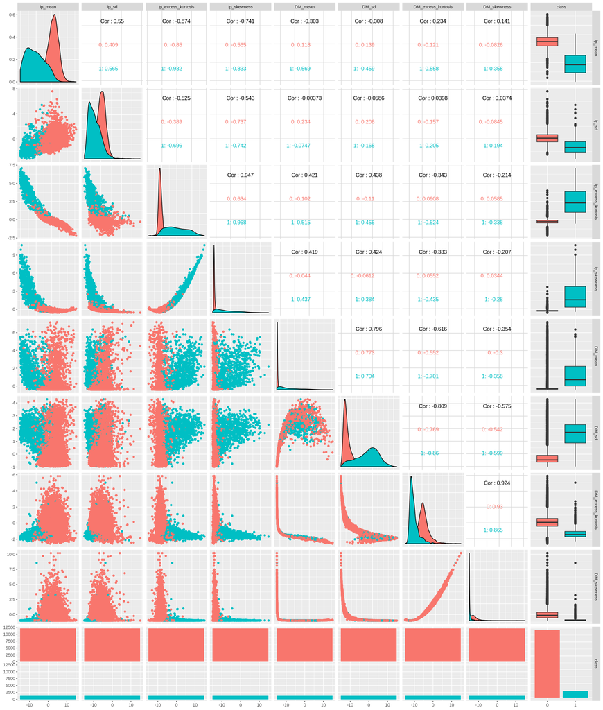

```r
options(repr.plot.width=17, repr.plot.height=20)
pairs_plot = ggpairs(training_set, aes(colour = as.factor(training_set$class)),
                     lower = list(combo = wrap(ggally_facethist, binwidth = 30)))
pairs_plot
```

# B2. Using Logistic Regression to determine the potentially ineffective column

Each observation in our dataset is categorized as non-pulsar(0) or pulsar(1), so we have a categorical dependent variable and a set of independent variables. In this case, logistic regression can provide an insight of which predictors might not be very useful to our prediction.

z and P>|z| – These columns provide the z-value and 2-tailed p-value used in testing the null hypothesis that the coefficient (parameter) is 0. If we were to conduct a hypothesis test on each column with the null hypothesis in which the coefficient is 0, and with an alpha level of 0.05, we would fail to reject the null hypothesis for DM_excess_kurtosis. The coefficient for DM_excess_kurtosis, which is 0.58325, is not significantly different from 0 using an alpha of 0.05 because its p-value is 0.1763, which is larger than 0.05.

If the coefficient of DM_excess_kurtosis is close to 0, it is likely not very influencial on the prediction of the final result in logistic regression. This tells us that DM_excess_kurtosis could also potentially be not very influencial in our knn prediction model. Therefore, we will choose DM_excess_kurtosis to be the column that will be removed from our second model.

`- Note: Although we have indirect evidence from the pairs plot and the logistic regression suggesting that DM_excess_kurtosis could be ineffective in our knn model, it is still very possible that excess_kurtosis could be valuable in a KNN model. We would like to emphasize DM_excess_kurtosis is POTENTIALLY ineffective, and we can only find out whether it's valuable or not after we have compared the accuracy of the 2 final models.`

```r
#logistic regression
test<-glm(class ~ ip_mean +
          ip_sd +
          ip_excess_kurtosis +
          ip_skewness +
          DM_mean +
          DM_sd +
          DM_excess_kurtosis +
          DM_skewness, family = binomial(link="logit"), data = training_set)

summary(test)
```

```
Call:
glm(formula = class ~ ip_mean + ip_sd + ip_excess_kurtosis +
    ip_skewness + DM_mean + DM_sd + DM_excess_kurtosis + DM_skewness,
    family = binomial(link = "logit"), data = training_set)

Deviance Residuals:
    Min       1Q   Median       3Q      Max
-4.4168  -0.1657  -0.1008  -0.0576   3.6060

Coefficients:
                   Estimate Std. Error z value Pr(>|z|)
(Intercept)        -4.30000    0.10078 -42.666  < 2e-16 ***
ip_mean             1.01018    0.17673   5.716 1.09e-08 ***
ip_sd              -0.38905    0.08596  -4.526 6.01e-06 ***
ip_excess_kurtosis  7.33179    0.37926  19.332  < 2e-16 ***
ip_skewness        -3.99281    0.28686 -13.919  < 2e-16 ***
DM_mean            -0.92513    0.11120  -8.319  < 2e-16 ***
DM_sd               1.23812    0.16207   7.639 2.18e-14 ***
DM_excess_kurtosis  0.58325    0.43128   1.352   0.1763
DM_skewness        -0.71559    0.35709  -2.004   0.0451 *
---
Signif. codes:  0 ‘***’ 0.001 ‘**’ 0.01 ‘*’ 0.05 ‘.’ 0.1 ‘ ’ 1

(Dispersion parameter for binomial family taken to be 1)

    Null deviance: 8207.4  on 13365  degrees of freedom
Residual deviance: 1958.9  on 13357  degrees of freedom
AIC: 1976.9

Number of Fisher Scoring iterations: 8
```

$\;\;\;\;\;\;$ $\;\;\;\;\;\;$

- We perform logistic regression again, except we remove the DM_excess_kurtosis column from our model this time. From the results, we observe that the P value of DM_skewness has significantly decreased, while the P values of other columns remain almost unchanged. This result aligns with our previous conclusion that DM_skewness and DM_excess_kurtosis are highly correlated columns.

```r
test_2<-glm(class ~ ip_mean +
          ip_sd +
          ip_excess_kurtosis +
          ip_skewness +
          DM_mean +
          DM_sd +
          DM_skewness, family = binomial(link="logit"), data = training_set)

summary(test_2)
```

```
Call:
glm(formula = class ~ ip_mean + ip_sd + ip_excess_kurtosis +
    ip_skewness + DM_mean + DM_sd + DM_skewness, family = binomial(link = "logit"),
    data = training_set)

Deviance Residuals:
    Min       1Q   Median       3Q      Max
-4.4072  -0.1655  -0.1010  -0.0582   3.6202

Coefficients:
                   Estimate Std. Error z value Pr(>|z|)
(Intercept)        -4.28858    0.09993 -42.914  < 2e-16 ***
ip_mean             1.00583    0.17672   5.692 1.26e-08 ***
ip_sd              -0.39416    0.08589  -4.589 4.46e-06 ***
ip_excess_kurtosis  7.28302    0.37696  19.320  < 2e-16 ***
ip_skewness        -3.97480    0.28470 -13.961  < 2e-16 ***
DM_mean            -0.97557    0.10499  -9.292  < 2e-16 ***
DM_sd               1.07706    0.11021   9.773  < 2e-16 ***
DM_skewness        -0.26334    0.12003  -2.194   0.0282 *
---
Signif. codes:  0 ‘***’ 0.001 ‘**’ 0.01 ‘*’ 0.05 ‘.’ 0.1 ‘ ’ 1

(Dispersion parameter for binomial family taken to be 1)

    Null deviance: 8207.4  on 13365  degrees of freedom
Residual deviance: 1960.7  on 13358  degrees of freedom
AIC: 1976.7

Number of Fisher Scoring iterations: 8
```

# C1. Partition the Data

Using the training_set and testing_set dataframe we previously generated, we create the four objects needed to train and test a model using the caret package:

1. Two data frames containing all the predictors for (X_train, X_test)
2. Two vectors containing the Class (the target variable).

```r
X_train <- training_set %>%
    select(-class) %>%
    data.frame()

Y_train <- training_set %>%
    select(class) %>%
    unlist()

X_test <- testing_set %>%
    select(-class) %>%
    data.frame()

Y_test <- testing_set %>%
    select(class) %>%
    unlist()
```

# C2.Train model with Train Control using many different k-values

We use a 5 fold cross validation to help us identify the k-value from 1 to 30 that yields the highest accuracy.

```r
set.seed(1234)

train_control <- trainControl(method="cv", number = 5)

k <- data.frame(k = c(seq(from = 1,to = 30)))

model_pulsar <- train(x = X_train, y = Y_train, method = "knn", tuneGrid = k, trControl = train_control)
model_pulsar
```

```
k-Nearest Neighbors

13366 samples
    8 predictor
    2 classes: '0', '1'

No pre-processing
Resampling: Cross-Validated (5 fold)
Summary of sample sizes: 10692, 10693, 10693, 10693, 10693
Resampling results across tuning parameters:

  k   Accuracy   Kappa
   1  0.9695496  0.8182366
   2  0.9681280  0.8073591
   3  0.9780038  0.8618186
```

[output cut: 30 more lines]

# C3.Display accuracies with different k-values in descending order, plot k vs Accuracy

Arranging the accuracies of the k-values from highest to lowest, we can see that a k value of 12 yields the highest accuracy of 0.9785. This result can be verified by graph, where the point labelled in red is the optimal k we found from the cross validation result.

A data.frame: 5 × 2

|  | k <int> | Accuracy <dbl> |
| --- | --- | --- |
| 1 | 12 | 0.9785274 |
| 2 | 19 | 0.9783778 |
| 3 | 10 | 0.9782282 |
| 4 | 11 | 0.9782282 |
| 5 | 5 | 0.9781534 |

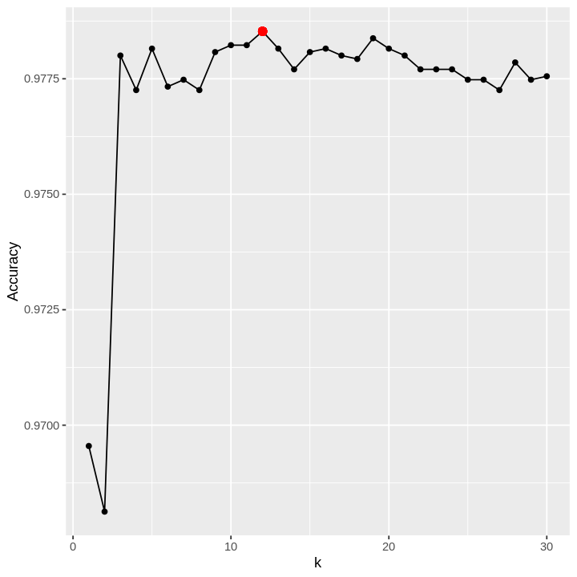

```r
k_accuracies <- model_pulsar$results %>%
                    select(k, Accuracy)

k_accuracies_arranged <- k_accuracies %>% arrange(desc(Accuracy)) %>% head(n = 5)
k_accuracies_arranged

options(repr.plot.width = 6, repr.plot.height = 6)
cross_val_plot <- k_accuracies %>% ggplot(aes(x = k, y = Accuracy)) +
  geom_point() +
  geom_line() +
  geom_point(aes(x =k_accuracies_arranged$k[1] , y = k_accuracies_arranged$Accuracy[1]), color = "red", size = 2.5)
cross_val_plot
```

# C4.Train final model with best k-value

```r
k_final = data.frame(k = k_accuracies_arranged$k[1])

model_final <- train(x = X_train, y = Y_train, method = "knn", tuneGrid = k_final)
model_final
```

```
k-Nearest Neighbors

13366 samples
    8 predictor
    2 classes: '0', '1'

No pre-processing
Resampling: Bootstrapped (25 reps)
Summary of sample sizes: 13366, 13366, 13366, 13366, 13366, 13366, ...
Resampling results:

  Accuracy   Kappa
  0.9774086  0.8561574

Tuning parameter 'k' was held constant at a value of 12
```

# C5.Assess final model

We then access the prediction accuracy of our model using the test set. We input X_test into our trained model and compare the results to the actual labels(Y_test). It can be concluded by the output of the following code cell that we have obtained a reasonably accurate model that identifies whether a star is polsar or not. The model has a testing accuracy of around 97.82% for the final model trained with the best k-value found.

```r
test_pred <- predict(model_final, X_test)
model_quality <- confusionMatrix(data = test_pred, reference = Y_test)

result <- data.frame(Model = "Using All Columns",
                    Best_k = k_final$k[1],
                     Model_Testing_Accuracy = model_quality$overall[[1]])

result
```

A data.frame: 1 × 3

| Model <fct> | Best_k <int> | Model_Testing_Accuracy <dbl> |
| --- | --- | --- |
| Using All Columns | 12 | 0.9782218 |

# D1. Repeat above steps but with DM_excess_kurtosis removed.

As mentioned in the previous steps, we chose DM_excess_kurtosis to be the column to be removed in our second model. Because the steps of obtaining the results of the second model is very similar to part `C`, we will not explain each step again in detail for the sake of avoiding unnecessary repetition. Furthermore, we chose to only display the plot showing the optimal k-value (k=19 in this case), and the table showing the final model accuracy on the test set.

A data.frame: 1 × 3

| Model <fct> | Best_k <int> | Model_Testing_Accuracy <dbl> |
| --- | --- | --- |
| Using All Columns except DM_excess_kurtosis | 19 | 0.9777728 |

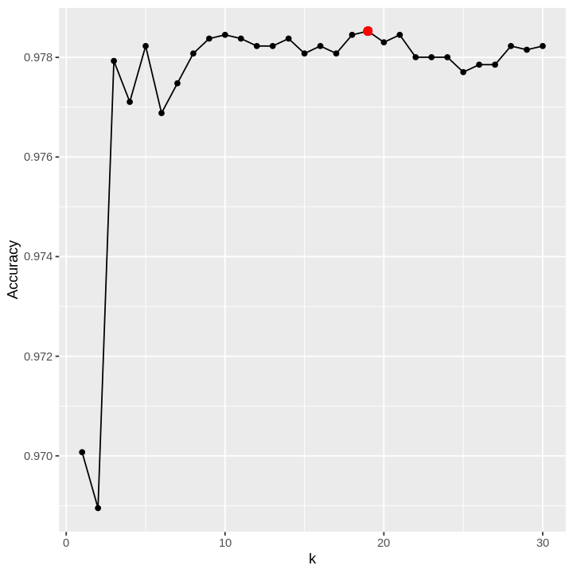

```r
# spliting the data into 4 data frames that we need to train and test the model
X_train_2 <- training_set %>%
    select(-class,-DM_excess_kurtosis) %>%
    data.frame()

Y_train_2 <- training_set %>%
    select(class) %>%
    unlist()

X_test_2 <- testing_set %>%
    select(-class,- DM_excess_kurtosis) %>%
    data.frame()

Y_test_2 <- testing_set %>%
    select(class) %>%
    unlist()
#------------------------------------------------------------------------------------------------------------
# Use a 5 fold cross validation to help us identify the k-value from 1 to 30 that yields the highest accuracy.
set.seed(1234)

train_control <- trainControl(method="cv", number = 5)

k <- data.frame(k = c(seq(from = 1,to = 30)))

model_pulsar_2 <- train(x = X_train_2, y = Y_train_2, method = "knn", tuneGrid = k, trControl = train_control)

#------------------------------------------------------------------------------------------------------------
# Identify the k-value that yields the highest accuracy
k_accuracies_2 <- model_pulsar_2$results %>%
                    select(k, Accuracy)

k_accuracies_arranged_2 <- k_accuracies_2 %>% arrange(desc(Accuracy)) %>% head(n = 5)



options(repr.plot.width = 6, repr.plot.height = 6)
cross_val_plot_2 <- k_accuracies_2 %>% ggplot(aes(x = k, y = Accuracy)) +
  geom_point() +
  geom_line() +
  geom_point(aes(x =k_accuracies_arranged_2$k[1] , y = k_accuracies_arranged$Accuracy[1]), color = "red", size = 2.5)
cross_val_plot_2
#------------------------------------------------------------------------------------------------------------
# train the final model with the optimal k-value generated
k_final_2 = data.frame(k = k_accuracies_arranged_2$k[1])

model_final_2 <- train(x = X_train_2, y = Y_train_2, method = "knn", tuneGrid = k_final_2)

#------------------------------------------------------------------------------------------------------------
# display the k-value, testing accuracy for the model
test_pred_2 <- predict(model_final_2, X_test_2)
model_quality_2 <- confusionMatrix(data = test_pred_2, reference = Y_test_2)

result_2 <- data.frame(Model = "Using All Columns except DM_excess_kurtosis",
                    Best_k = k_final_2$k[1],
                     Model_Testing_Accuracy = model_quality_2$overall[[1]])

result_2
#------------------------------------------------------------------------------------------------------------
```

# D2. Analysis of result of model 2

After removing DM_excess_kurtosis from our model, we found the optimal k-value to be 19. The final testing accuracy is 0.9777728, which is a fairly high accuracy.

# E1. Conclusion

Combining the two results table , we can compare the accuracy of the 2 models. It is clear the second model has a testing accuracy very close to the testing accuracy of the first model. This implies that we can use all the features/predictors related to the Integrated Profile and DM-SNR curve except for DM_excess_kurtosis, and still build a model that is very similar in accuracy as a model that is built using all the columns as predictors. This aligns with our hypothesis that removing the potentially insignificant column, in this case DM_excess_kurtosis, will still give us a model that predicts pulsars fairly accurately.

```r
result <- rbind(result, result_2)
result
```

A data.frame: 2 × 3

| Model <fct> | Best_k <int> | Model_Testing_Accuracy <dbl> |
| --- | --- | --- |
| Using All Columns | 12 | 0.9782218 |
| Using All Columns except DM_excess_kurtosis | 19 | 0.9777728 |

# E2. Impact and Future Questions

Pulsars are fantastic cosmic tools for scientists to study a wide range of phenomena. Pulsars are proved to be extremely useful because of the precision of their pulses. In general, optimizing the prediction model used to accurately predict pulsar stars from radio emissions is also a very important topic to researchers. Using one less predictor might not seem very significant, but it will actually greatly reduce the computation power required when performing Cross Validation and training the model especially when datasets are extremely large.

However, there are a few limitations to our findings. It is not statistically proven that the accuracy of our second model is as similar as the first model. Although in our case, using all columns as predictors yielded a slightly higher accuracy than not using DM_excess_kurtosis column, it is very possible that the second model will perform slightly better if we used a different seed to partition our original dataset. To prove whether the accuracy of the two models are statitically different, we would potentially need to conduct a hypothesis test on the true mean difference of model 1 and model 2.

Another future topic to investigate is whether or not we can generalize our result and applying it to other models that predict things other than pulsars. In other words, if we identify a feature of the dataset to be highly correlated to another feature, and is shown to have a coefficient close to 0 in logistic regression, then we can choose to remove this feature when building a knn model. We will potentially be able to replicate what we did in this project in regards to optimizing a knn classification model and apply it to other datasets outside of pulsars. However, these potential future research topics will require a lot more sophisticated computation and testing.

# E3. Acknowledgements

We would like to thank the entire DSCI 100 teaching team for doing such an amazing job of making sure the students have a firm grasp of the concepts at hand, and placing the emphasis on understanding as opposed to just formulas and numbers. Our group members have all definitely learned a lot, which we've put to use in this project. We would also like to thank Hayden, our TA Mentor for this project, in particular. Hayden has provided very helpful guidance along the way and has always been happy to help when we ran into issues.

# E4. Citations

Cofield, C. (2016, April 22). What Are Pulsars? Retrieved April 1, 2020, from https://www.space.com/32661-pulsars.html

Observations of Pulsars. (n.d.). Retrieved April 1, 2020, from http://www.jb.man.ac.uk/distance/frontiers/pulsars/section4.html

Noise-to-Signal Ratio. (n.d.). Retrieved April 1, 2020, from https://www.sciencedirect.com/topics/computer-science/noise-to-signal-ratio

R. J. Lyon, B. W. Stappers, S. Cooper, J. M. Brooke, J. D. Knowles, Fifty Years of Pulsar Candidate Selection: From simple filters to a new principled real-time classification approach, Monthly Notices of the Royal Astronomical Society 459 (1), 1104-1123, DOI: 10.1093/mnras/stw656